# Recomendador de vinos (Tarea 4)

Mario Guillem

27/12/2022

## Introducción

En esta práctica vamos a realizar un sistema de recomendación colaborativo basado en productos, en nuestro caso los productos a recomendar serán vinos. La base de datos cuenta con un total de 129971 observaciones y 14 variables.

```r
df <- read.csv("C:/Users/Mario/Desktop/wines.csv")

#Buscamos NA's en la base de datos:
sum(is.na(df))
```

```
## [1] 8996
```

```r
nulls <- sapply(df, function(x) sum(is.na(x)))
nulls
```

```
##                     X               country           description
##                     0                     0                     0
##           designation                points                 price
##                     0                     0                  8996
##              province              region_1              region_2
##                     0                     0                     0
##           taster_name taster_twitter_handle                 title
##                     0                     0                     0
##               variety                winery
##                     0                     0
```

Podemos observar como la única columna que cuenta con NA’s es la de los precios, es por ello que vamos a reemplazar los NA’s (8996) por la media ya que eliminarlos directamente nos parecería reducir signifactivamente nuestro dataset, estaríamos eliminando casi el 7% de las observaciones.

### Sustitución de NA’s

Para sustituir los NA’s por la media de los precios utilizaremos la funcion imputeTS.

```r
media <- df%>%
  na_mean()

df <- media

#Eliminamos las valoraciones duplicadas.
df <- df[!duplicated(df[,c("taster_name", "title")]),]
```

## Exploratory Data Analysis

A continuación, vamos a analizar los vinos de nuestro dataset:

```r
# MEJORES VINOS:

mej_vinos = df %>%
  select(title, price, points) %>%
  filter(title != '' & points == 100) %>%
  arrange(price) %>%
  head(10)

(mej_vinos)
```

```
##                                                              title price points
## 1       Charles Smith 2006 Royal City Syrah (Columbia Valley (WA))    80    100
## 2          Cayuse 2008 Bionic Frog Syrah (Walla Walla Valley (WA))    80    100
## 3                       Château Léoville Barton 2010  Saint-Julien   150    100
## 4                  Cardinale 2006 Cabernet Sauvignon (Napa Valley)   200    100
## 5  Avignonesi 1995 Occhio di Pernice  (Vin Santo di Montepulciano)   210    100
## 6            Louis Roederer 2008 Cristal Vintage Brut  (Champagne)   250    100
## 7                                      Krug 2002 Brut  (Champagne)   259    100
## 8       Casanova di Neri 2007 Cerretalto  (Brunello di Montalcino)   270    100
## 9          Chambers Rosewood Vineyards NV Rare Muscat (Rutherglen)   350    100
## 10                   Château Léoville Las Cases 2010  Saint-Julien   359    100
```

```r
# PEORES VINOS:

peores = df %>%
  select(title, price, points) %>%
  filter(title != '' & points < 85) %>%
  arrange(points) %>%
  head(10)

peores
```

```
##                                                              title price points
## 1        Viña Tarapacá 2015 Gran Reserva Chardonnay (Leyda Valley)    19     80
## 2                        Viniverde 2011 Estreia Rosé (Vinho Verde)     8     80
## 3            Cuevas del Sur 2010 Reserve Chardonnay (Maule Valley)    15     80
## 4  Fattoria Giuseppe Savini 2011 Rondineto Merlot (Colli Aprutini)    12     80
## 5                        Paul Cheneau NV Demi Sec Sparkling (Cava)    14     80
## 6                   Bodega Carmine Granata 2009 Sémillon (Mendoza)    17     80
## 7                    Cruz Alta 2007 Grand Reserve Malbec (Mendoza)    20     80
## 8                           Ricardo Santos 2009 Sémillon (Mendoza)    15     80
## 9                                  Gardel 2009 Torrontés (Mendoza)    12     80
## 10 Alma del Sur 2009 Colección Cabernet Sauvignon-Malbec (Mendoza)    12     80
```

```r
# MÁS CAROS:

caros = df %>%
  select(title, price, points) %>%
  filter(title != '') %>%
  mutate(price = as.integer(price)) %>%
  arrange(desc(price)) %>%
  head(10)

caros
```

```
##                                                      title price points
## 1                     Château les Ormes Sorbet 2013  Médoc  3300     88
## 2                             Château Pétrus 2014  Pomerol  2500     96
## 3           Domaine du Comte Liger-Belair 2010  La Romanée  2500     96
## 4  Blair 2013 Roger Rose Vineyard Chardonnay (Arroyo Seco)  2013     91
## 5                             Château Pétrus 2011  Pomerol  2000     97
## 6           Domaine du Comte Liger-Belair 2005  La Romanée  2000     96
## 7                            Château Margaux 2009  Margaux  1900     98
## 8                 Château Lafite Rothschild 2010  Pauillac  1500    100
## 9                 Château Cheval Blanc 2010  Saint-Émilion  1500    100
## 10                Château Mouton Rothschild 2009  Pauillac  1300     96
```

```r
#MÁS BARATOS:

baratos = df %>%
  select(title, price, points) %>%
  filter(title != '' & price < 10 & points >= 90) %>%
  mutate(price = as.integer(price)) %>%
  arrange(price) %>%
  head(10)

baratos
```

```
##                                                                             title
## 1                             Herdade dos Machados 2012 Toutalga Red (Alentejano)
## 2                                      Esser Cellars 2001 Chardonnay (California)
## 3              Snoqualmie 2006 Winemaker's Select Riesling (Columbia Valley (WA))
## 4  Aveleda 2013 Quinta da Aveleda Estate Bottled Loureiro-Alvarinho White (Minho)
## 5                       Rothbury Estate 2001 Chardonnay (South Eastern Australia)
## 6                    Mano A Mano 2011 Tempranillo (Vino de la Tierra de Castilla)
## 7               Aveleda 2014 Quinta da Aveleda Estate Bottled White (Vinho Verde)
## 8                      Chateau Ste. Michelle 2011 Riesling (Columbia Valley (WA))
## 9               Aveleda 2012 Quinta da Aveleda Estate Bottled White (Vinho Verde)
## 10                                              DFJ Vinhos 2011 Paxis Red (Douro)
##    price points
## 1      7     91
## 2      8     90
## 3      8     91
## 4      8     90
## 5      8     90
## 6      9     90
## 7      9     90
## 8      9     91
## 9      9     90
## 10     9     90
```

```r
# MEJORES CALIDAD-PRECIO:

cal.pre = df %>%
  select(title, price, points) %>%
  filter(title != '' & points > 95) %>%
  mutate(price = as.integer(price)) %>%
  arrange(price) %>%
  head(10)

cal.pre
```

```
##                                                             title price points
## 1                          Rulo 2007 Syrah (Columbia Valley (WA))    20     96
## 2                            Isole e Olena 2010  Chianti Classico    27     96
## 3           Donkey & Goat 2012 Grenache Noir Grenache (El Dorado)    27     96
## 4       The Eyrie Vineyards 2014 Estate Chardonnay (Dundee Hills)    27     96
## 5                                  Château Filhot 2014  Sauternes    28     96
## 6              Eichinger 2014 Gaisberg Reserve Riesling (Kamptal)    28     96
## 7  Domaines Schlumberger 2014 Saering Grand Cru Riesling (Alsace)    29     96
## 8              Efeste 2009 Lola Chardonnay (Columbia Valley (WA))    30     96
## 9                 Sineann 2015 TFL Pinot Noir (Willamette Valley)    30     96
## 10 Trisaetum 2016 Ribbon Ridge Estate Dry Riesling (Ribbon Ridge)    32     96
```

## Preprocesamiento de los datos

Antes de realizar el sistema de recomendación nos aseguraremos que nuestra base de datos se encuentra completa y con valores únicos, ya que si hubieran valores repetidos nos recomendaría ese mismo vino ya que la similitud sería máxima. Por otro lado, tan sólo nos quedaremos con los usuarios que hayan realizado más de 100 valoraciones. Entendemos que tendrán una mayor experiencia y sus valoraciones serán más fiables.

```r
#Nos aseguramos que no haya ningún nombre del catador vacío ni el título o nombre del vino vacío.

rating_df <- df %>% select(taster_name, title, points) %>% filter(taster_name != '' & title != '') %>% mutate(points = as.numeric(points)) %>% drop_na()

#Eliminamos los duplicados como hemos hecho anteriormente.
rating_df <- rating_df[!duplicated(rating_df[,c("taster_name", "title")]),]

#Creamos la matriz de valoraciones
rating_matrix <- as(rating_df, "realRatingMatrix")
print(paste(dim(rating_matrix)[1], 'users rated', dim(rating_matrix)[2], 'wines'))
```

```
## [1] "19 users rated 94149 wines"
```

```r
ratings <- as.vector(rating_matrix@data)
ratings <- round(ratings)
ratings <- factor(ratings)
ratings <- ratings[ratings != 0]

#Vemos cuantos vinos han recibido cada valoración:
table(ratings)
```

```
## ratings
##     0    80    81    82    83    84    85    86    87    88    89    90    91
##     0   274   426  1029  2058  4190  6714  8630 11395 12495  9556 11509  8925
##    92    93    94    95    96    97    98    99   100
##  7187  5084  2880  1187   400   163    61    20    13
```

```r
temp_df <- df %>% filter(points >= 90)
temp_df$points = as.character(temp_df$points)

n_user_ratings = rowCounts(rating_matrix)
n_user_ratings
```

```
## Alexander Peartree Anna Lee C. Iijima   Anne Krebiehl MW       Carrie Dykes
##                383               4012               3253                129
##  Christina Pickard        Fiona Adams       Jeff Jenssen         Jim Gordon
##                  6                 24                436               3750
##     Joe Czerwinski      Kerin O’Keefe      Lauren Buzzeo      Matt Kettmann
##               4753               9662               1700               5698
##  Michael Schachner      Mike DeSimone       Paul Gregutt         Roger Voss
##              13944                460               8856              22973
##   Sean P. Sullivan    Susan Kostrzewa     Virginie Boone
##               4448               1020               8689
```

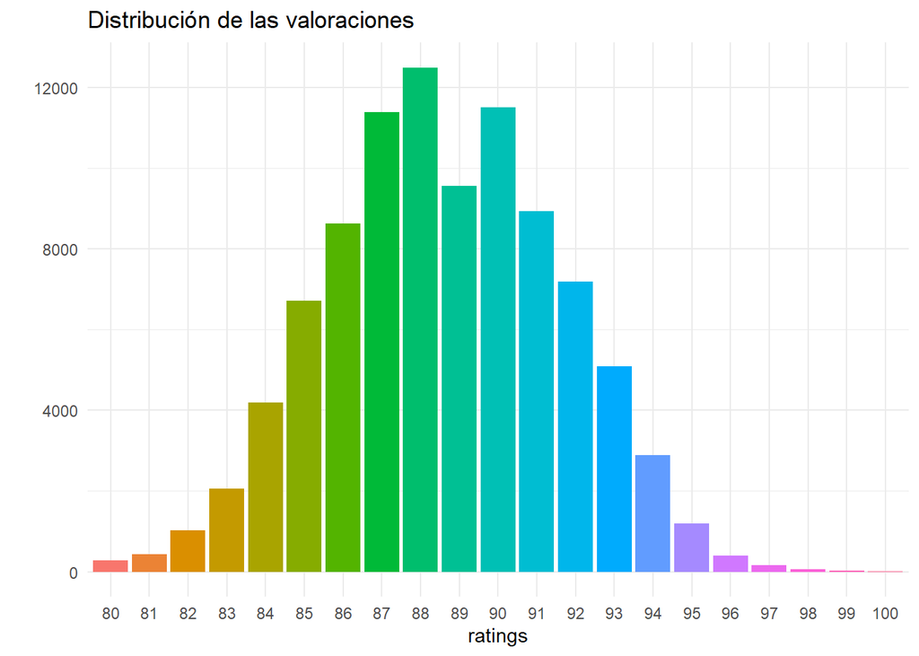

```r
rating_matrix <- rating_matrix[n_user_ratings > 100]

qplot(ratings,
      fill=ratings
     ) + ggtitle("Distribución de las valoraciones") + theme_minimal() +
     theme(legend.position = "none")
```

Podríamos decir que la distribución de las valoraciones se asemeja a una distribución normal.

## Sistema de Recomendación Colaborativo Basado en Vinos

```r
cos_similarity = function(A,B){
  A = as.numeric(A)
  B = as.numeric(B)
  num = sum(A * B, na.rm = T)
  den = sqrt(sum(A^2, na.rm = T)) * sqrt(sum(B^2, na.rm = T))
  output = num/den

  return(output)
}


matrix_item = rating_df %>%
  group_by(title) %>%
  pivot_wider(names_from = title, values_from = points) %>%
  as.data.frame()

row.names(matrix_item) = matrix_item$taster_name
matrix_item$taster_name = NULL

matrix_item = as.matrix(matrix_item)

recomendador = function(wine_name, rating_matrix = matrix_item, n_recommendations = 10){
  print(paste('Vinos similares a: ', wine_name))

  indice = which(colnames(rating_matrix) == wine_name)
  similarity = apply(rating_matrix, 2, FUN = function(y) cos_similarity(rating_matrix[,indice], y))

  vinos_similares = tibble(Wine = names(similarity),
                         similarity = similarity
  ) %>%
    filter(Wine != wine_name & similarity >= 0.5) %>%
    top_n(n_recommendations, similarity) %>%
    arrange(desc(similarity)) %>%
    head(n_recommendations)

  recomendaciones = df %>%
    filter(title %in% vinos_similares$Wine) %>%
    mutate(similarity = vinos_similares$similarity) %>%
    group_by(title) %>% select(title, price, points, country)

  return(recomendaciones)

}

#Ejemplo de uso del recomendador:

recomendador("Louis M. Martini 2012 Cabernet Sauvignon (Alexander Valley)")
```

```
## [1] "Vinos similares a:  Louis M. Martini 2012 Cabernet Sauvignon (Alexander Valley)"
```

```
## # A tibble: 10 × 4
## # Groups:   title [10]
##    title                                                    price points country
##    <chr>                                                    <dbl>  <int> <chr>
##  1 Kirkland Signature 2011 Mountain Cuvée Cabernet Sauvign…    19     87 US
##  2 Castello di Amorosa 2011 King Ridge Vineyard Pinot Noir…    69     87 US
##  3 Clarksburg Wine Company 2010 Chenin Blanc (Clarksburg)      16     86 US
##  4 Souverain 2010 Chardonnay (North Coast)                     14     85 US
##  5 Okapi 2013 Estate Cabernet Sauvignon (Napa Valley)         100     86 US
##  6 Eco Terreno 2013 Old Vine Cabernet Sauvignon (Alexander…    40     86 US
##  7 Hindsight 2013 Bella Vetta Vineyard Cabernet Sauvignon …    75     86 US
##  8 Hindsight 2012 Estate Grown Petite Sirah (Calistoga)        55     86 US
##  9 Mulvane Wine Co. 2013 The Cypher Red (Napa Valley)          75     86 US
## 10 Napa Cellars 2014 Classic Zinfandel (Napa Valley)           24     86 US
```